# 18 Federated Learning and Transfer Learning

Author

Tim RÖßling

## 18.1 Overview

This lecture covers advanced concepts in Machine Learning and Deep Learning, including:

- **Federated Learning**: Collaborative training without sharing private data.
- **Transfer Learning**: Adapting pre-trained models for new tasks.
- **Reinforcement Learning**: Learning through rewards and actions (briefly introduced).
- **Explainable Artificial Intelligence**: Understanding AI decisions (briefly introduced).

## 18.2 Federated Learning (FL)

### 18.2.1 What is Federated Learning?

- **Introduced by Google in 2016**: A decentralized approach to train AI models.
- **Key Idea**: Process data at its source (e.g., user devices) without centralizing sensitive data.
- **Benefits**:
  - Protects user privacy by avoiding raw data sharing.
  - Enables collaborative training across distributed devices.
- **Financial Application**: Banks can aggregate customer data to improve credit scores or fraud detection without compromising privacy.

### 18.2.2 How Does FL Work?

1. **Model Distribution**: A central server shares a pre-trained model with remote devices.
2. **Local Training**: Each device trains the model on its private data.
3. **Update Sharing**: Devices summarize and encrypt model updates (e.g., gradients) and send them to the server.
4. **Aggregation**: The server decrypts, averages updates, and integrates them into the global model.
5. **Iteration**: Steps repeat until the model is fully trained.

### 18.2.3 Workflow Diagram

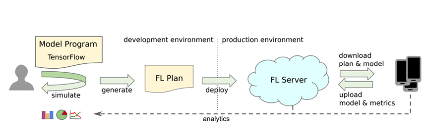

Federated Learning Workflow

### 18.2.4 Approach of FL

- **Privacy Guarantee**: Devices exchange model gradients, not raw data.
- **Process**:
  1. Local training on each device.
  2. Upload local model updates to the server.
  3. Server aggregates updates into a new global model.
  4. Distribute the updated model back to devices.

### 18.2.5 Training Process

1. **Horizontal Learning**: Trains on similar datasets across devices.
2. **Vertical Learning**: Combines complementary data (e.g., movie and book reviews to predict music preferences).
3. **Transfer Learning**: Adapts a pre-trained model to a new task (e.g., car detection to cat detection).

### 18.2.6 Centralized-Server Approach

- **Addresses Privacy Challenges**: Avoids pooling sensitive data, unlike traditional ML.

## 18.3 Transfer Learning (TL)

### 18.3.1 What is Transfer Learning?

- **Definition**: Fine-tuning a pre-trained model for a new, related task.
- **Example**: A model trained to identify dogs can be retrained to identify cats with a smaller dataset.
- **Advantages**:
  - Reduces training time and cost.
  - Widely used in NLP and image processing.
- **Application**: Critical for adopting generative AI across industries.

### 18.3.2 TL Strategies

1. **Transductive Transfer Learning**:
   - Transfers knowledge from a specific source to a related target domain.
   - **Advantage**: Works with little/no labeled target data.
   - **Example**: Sentiment analysis model from product reviews adapted for movie reviews.
2. **Inductive Transfer Learning**:
   - Same domain, different tasks.
   - **Advantage**: Faster training with pre-trained familiarity.
   - **Example**: NLP model pre-trained on text, fine-tuned for sentiment analysis.
3. **Unsupervised Transfer Learning**:
   - Uses unlabeled data in source and target domains.
   - **Example**: Identifying motorcycle types from unlabeled vehicle images.

### 18.3.3 TL Steps

1. **Select Pre-trained Model**: Choose a model with prior knowledge (e.g., ImageNet for images).
2. **Configure Model**:
   - **Freeze Layers**: Preserve source knowledge by locking pre-trained layers.
   - **Adjust Weights**: Start with random weights and refine during training.
   - **Modify Layers**: Remove the last layer and add new layers for the target task.
3. **Train on Target Domain**: Fine-tune with target data.

### 18.3.4 Python Example: Transfer Learning with TensorFlow

```python
import tensorflow as tf
from tensorflow.keras.applications import VGG16
from tensorflow.keras import layers, models

# Load pre-trained VGG16 model (without top layer)
base_model = VGG16(weights='imagenet', include_top=False, input_shape=(224, 224, 3))

# Freeze pre-trained layers
base_model.trainable = False

# Add custom layers for new task
model = models.Sequential([
    base_model,
    layers.Flatten(),
    layers.Dense(256, activation='relu'),
    layers.Dense(1, activation='sigmoid')  # Binary classification (e.g., cats vs. dogs)
])

# Compile the model
model.compile(optimizer='adam', loss='binary_crossentropy', metrics=['accuracy'])

# Summary
model.summary()
```

## 18.4 Privacy-Accuracy Trade-off

- **Issue**: Attackers may attempt to steal user data or hijack an AI model.
- **Challenge in FL**: When a data host exchanges their working model with the central server, it improves the model but leaves the data used for training vulnerable to inference attacks.
- **Reason for Exchange**: Each exchange enhances the model but increases the risk of privacy breaches.
- **Key Concern**: The more rounds of information exchanged, the easier it becomes to infer sensitive information.
- **Current Trend**: Research focuses on minimizing and neutralizing privacy threats to ensure secure federated learning.

## 18.5 Other Challenges in Federated Learning

1. **High Network Bandwidth**: Communication between devices and the central server can be resource-intensive.
2. **Transparency**: Ensuring that training data remains private while maintaining:
   - Testing accuracy.
   - Fairness in predictions.
   - Mitigation of potential biases in the model’s output.
3. **Accountability**: Logging and auditing each stage of the training pipeline to ensure traceability.
4. **Data Control**:
   - **Key Questions**:
     - What data are used to train the model?
     - How can data be deleted when a host leaves the federation?
   - **Rule**: If data are deleted, all parties are obligated to retrain the model from scratch to ensure compliance.
5. **Trust Issues**: Establishing trust among participants in the federation to prevent malicious behavior or data misuse.